# Pi estimation using simulation

Mario Becerra

September 8, 2017

There are many ways to estimate the value of $\pi$, some more efficient than others. One of them is using Monte Carlo simulation. The idea is that if you have a circle of radius 1, it will have an area of $\pi$. You can fit a circle within a square of area 4, such that they both have a centroid in the origin, like shown in the following image.

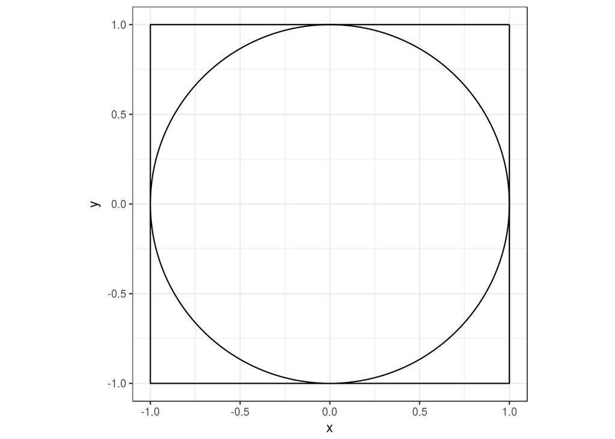

Then, if one simulates $N$ points in the square, counts how many were inside the circle ($N_{in}$) and computes $\frac{N_{in}}{N}$, one gets a number close to $\frac{\pi}{4}$. And the bigger $N$ gets, the closer one is to the real value of $\pi$. So, to estimate $\pi$, one computes $4\frac{N_{in}}{N}$. An example of the simulated points can be seen in the following figure (done in R).

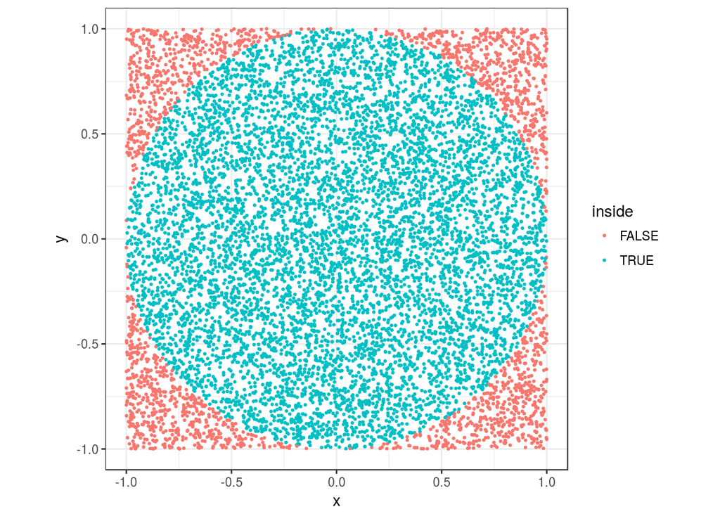

```r
tibble(x = runif(10000, -1, 1),
               y = runif(10000, -1, 1)) %>%
  mutate(inside = x^2 + y^2 < 1) %>%
  ggplot() +
  geom_point(aes(x, y, color = inside), size = 0.5) +
  coord_equal() +
  theme_bw()
```

Now, let’s see how close we get to the value of $\pi$ as we use more and more points. The following image shows the estimate that we get for each $N$. We can see that as $N$ grows, we get closer and closer to the real value shown with the red horizontal line.

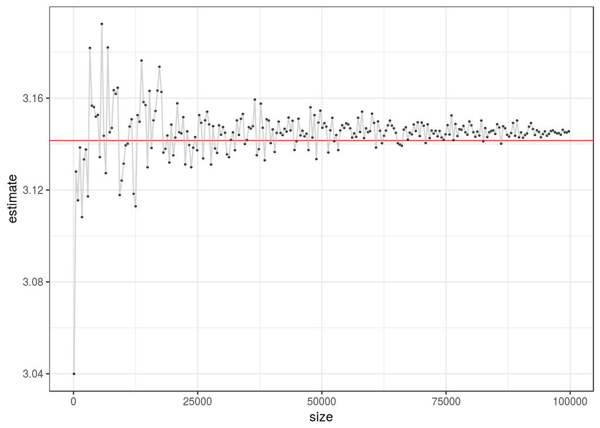

```r
N <- 100000

data <- tibble(x = runif(N, -1, 1),
               y = runif(N, -1, 1)) %>%
  mutate(inside = x^2 + y^2 < 1)

sizes <- seq(100, N, 400)

estimate <- sapply(sizes, function(n){
  data2 <- data %>%
    sample_n(n)
  4*sum(data2$inside)/nrow(data2)
})


tibble(size = sizes,
       estimate = estimate) %>%
  ggplot(aes(size, estimate)) +
  geom_hline(yintercept = pi, size = 0.3, color = 'red') +
  geom_point(size = 0.3) +
  geom_line(group = 1, color = 'dark grey', alpha = 0.5) +
  theme_bw()
```

We can see that the rate of convergence is slow. We had to simulate many points to get relatively close to the value of $\pi$. There are many more efficient methods to do this, but it’s nice to see how with simulation we can get also estimate it.